# 06-tcell-cd8-pathway-enrichment

Bicna Song

2026-11-04

## Purpose

This analysis asks which biological programs go up or down along each shared CD4-like and CD8-like lineage, from its start to its endpoint. The results are one line of evidence for the reviewed lineage labels in `config/tcell-lineage-annotation-manifest.tsv`, alongside the stage 04 tradeSeq gene trends and the ProjecTILs labels. The main outputs are a per-lineage table of each lineage’s top pathways and a pathway-by-lineage figure.

**How genes are ranked.** Within each lineage, genes are ranked by their fitted change from start to endpoint: the log2 ratio `(end + 0.1) / (start + 0.1)` from the stage 04 tradeSeq model, averaged across conditions. No significance cutoff is applied. Genes that tradeSeq could not test in any condition of that lineage are left out, because their fitted endpoints have no data behind them and can be extreme (for example +173 log2).

**How to interpret the results.**

- Enrichment is measured against the ~3,000 variable genes modeled in stage 04, not the whole transcriptome. Each lineage uses only its testable subset of those genes, so compare lineages by direction and FDR rather than small NES differences.
- Results are cell-level and describe start-to-endpoint change only, so programs that peak mid-lineage are not captured.
- CD8 lineage 3 has sparse support in some conditions; interpret it with caution.
- Hallmark and GO BP have no exhaustion set. For CD8 only, four published CD8 T-cell signatures (Miller et al. 2019: progenitor exhausted, effector-like, terminally exhausted and proliferating) are therefore also tested, as a prespecified set reported in full. The progenitor signature is dominated by ribosomal and mitochondrial genes, so it is less specific.

## Setup

This chunk loads the enrichment packages, defines output directories and loads the independent pathway helpers. Use the project Docker image; no upstream analysis helpers are sourced.

```r
Sys.setenv(OMP_NUM_THREADS = "1", OPENBLAS_NUM_THREADS = "1", MKL_NUM_THREADS = "1")
suppressPackageStartupMessages({
  library(rprojroot)
  library(dplyr)
  library(tibble)
  library(purrr)
  library(ggplot2)
  library(stringr)
  library(BiocParallel)
  library(msigdbr)
  library(fgsea)
})
root_dir <- find_root(has_dir(".git"))
analysis_dir <- file.path(root_dir, "analyses", "tcell-trajectory-analysis")
tradeseq_dir <- file.path(analysis_dir, "results", "cd4-cd8-tradeseq")
results_dir <- file.path(analysis_dir, "results", "cd4-cd8-pathway-enrichment")
plot_dir <- file.path(analysis_dir, "plots", "cd4-cd8-pathway-enrichment")
walk(c(results_dir, plot_dir), dir.create, recursive = TRUE, showWarnings = FALSE)
helper_file <- file.path(analysis_dir, "util", "tcell_pathway_enrichment_helpers.R")
source(helper_file)
if (as.character(packageVersion("msigdbr")) != "25.1.1" ||
    as.character(packageVersion("fgsea")) != "1.32.4") {
  stop("Use the project Docker image with msigdbr 25.1.1 and fgsea 1.32.4")
}
```

## Parameters

This chunk selects compartments and records the pathway size, FDR, random seed and cache settings. Both compartments use the same 100,000 initial permutations and enrichment settings. Hallmark (`MH`) is the primary collection; GO Biological Process (`M5/GO:BP`) is supporting detail. Both come from the mouse database release pinned by the installed msigdbr version. A single worker is adequate to start; `FGSEA_WORKERS` can increase parallelism without loading large fitted models. For repeat runs, use the same project Docker image, saved input tables, frozen gene-set snapshot and worker count. Each job fixes its RNG algorithm and seed independently of earlier R commands; seeds are unchanged when compartments run separately or together.

```r
requested_compartment <- as.character(params$compartment)
compartment_stems <- c(`CD4-like` = "cd4", `CD8-like` = "cd8")
if (length(requested_compartment) != 1L || is.na(requested_compartment) ||
    !requested_compartment %in% c("both", names(compartment_stems))) {
  stop("compartment must be both, CD4-like or CD8-like")
}
selected_compartments <- if (requested_compartment == "both") names(compartment_stems) else requested_compartment
collections <- c("Hallmark", "GO_BP")
# CD8-only prespecified signatures (Miller et al. 2019, PMC6673650, supplementary table 1).
signature_collection <- "Miller2019_CD8"
signature_file <- file.path(analysis_dir, "input", "NIHMS1026478-supplement-SUPPTB1.xlsx")
compartment_collections <- list(`CD4-like` = collections,
  `CD8-like` = c(collections, signature_collection))
msigdb_version <- "2025.1.Mm"
min_pathway_size <- 15L
max_pathway_size <- 500L
review_fdr <- 0.05
top_pathways_per_direction <- 4L
max_review_jaccard <- 0.5
# Figure pages with fewer pathway rows use a fixed, compact dot spacing.
compact_max_rows <- 10L
analysis_seed <- 1234L
fgsea_eps <- 1e-10
# Increase the initial permutations to reduce unavailable pathway estimates.
fgsea_n_perm_simple <- 100000L
force_enrichment <- FALSE
workers <- suppressWarnings(as.integer(Sys.getenv("FGSEA_WORKERS", "1")))
if (is.na(workers) || workers < 1L) stop("FGSEA_WORKERS must be a positive integer")
gene_set_file <- file.path(results_dir, paste0("mouse_msigdb_", msigdb_version, "_gene_sets.tsv.gz"))
```

## Load and validate fitted changes

This chunk verifies unique modeled genes, convergence and all three reviewed lineages. It prints the number of genes ranked and excluded per lineage, by reason. Input checksums are printed here and embedded in enrichment caches; no separate input-manifest file is written.

```r
annotation_file <- file.path(analysis_dir, "config", "tcell-lineage-annotation-manifest.tsv")
annotations <- read.delim(annotation_file, stringsAsFactors = FALSE, check.names = FALSE)
if (!all(c("compartment", "lineage", "assigned_program") %in% names(annotations)) ||
    anyNA(annotations[c("compartment", "lineage", "assigned_program")]) ||
    anyDuplicated(annotations[c("compartment", "lineage")])) {
  stop("The lineage annotation manifest is incomplete or duplicated")
}
ranking_files <- setNames(file.path(tradeseq_dir, paste0("tcell_",
  compartment_stems[selected_compartments], "_tradeseq_lineage_rankings.tsv")), selected_compartments)
qc_files <- setNames(file.path(tradeseq_dir, paste0("tcell_",
  compartment_stems[selected_compartments], "_tradeseq_gene_fit_qc.tsv")), selected_compartments)
ranking_inputs <- imap(ranking_files, function(file, compartment) {
  expected <- annotations$lineage[annotations$compartment == compartment]
  if (!setequal(expected, paste0("slingPseudotime_", 1:3))) {
    stop("Expected three reviewed shared lineages for ", compartment)
  }
  read_pathway_rankings(file, qc_files[[compartment]], compartment, annotations)
})
knitr::kable(bind_rows(map(ranking_inputs, "summary")))
```

| compartment | lineage | n_modeled | n_used | n_not_converged | n_nonfinite_endpoint | n_no_testable_association | n_positive | n_negative | n_zero | n_ties |
| --- | --- | --- | --- | --- | --- | --- | --- | --- | --- | --- |
| CD8-like | slingPseudotime_1 | 3001 | 2244 | 0 | 2 | 755 | 1369 | 819 | 56 | 55 |
| CD8-like | slingPseudotime_2 | 3001 | 2408 | 0 | 2 | 591 | 1711 | 651 | 46 | 46 |
| CD8-like | slingPseudotime_3 | 3001 | 1802 | 0 | 2 | 1197 | 1040 | 731 | 31 | 31 |

```r
knitr::kable(bind_rows(map(ranking_inputs, "excluded")) %>%
  count(compartment, lineage, analysis_status, name = "n_genes_excluded"))
```

| compartment | lineage | analysis_status | n_genes_excluded |
| --- | --- | --- | --- |
| CD8-like | slingPseudotime_1 | no_testable_association | 755 |
| CD8-like | slingPseudotime_1 | nonfinite_endpoint | 2 |
| CD8-like | slingPseudotime_2 | no_testable_association | 591 |
| CD8-like | slingPseudotime_2 | nonfinite_endpoint | 2 |
| CD8-like | slingPseudotime_3 | no_testable_association | 1197 |
| CD8-like | slingPseudotime_3 | nonfinite_endpoint | 2 |

```r
input_checksums <- tools::md5sum(c(ranking_files, qc_files, annotation_file))
knitr::kable(tibble(file = names(input_checksums), md5 = unname(input_checksums)))
```

| file | md5 |
| --- | --- |
| /home/rstudio/haydar-scrna/analyses/tcell-trajectory-analysis/results/cd4-cd8-tradeseq/tcell_cd8_tradeseq_lineage_rankings.tsv | 37da394cc995834c43f08727defb8c61 |
| /home/rstudio/haydar-scrna/analyses/tcell-trajectory-analysis/results/cd4-cd8-tradeseq/tcell_cd8_tradeseq_gene_fit_qc.tsv | b13b853291f6015902046b3c1ac4d42e |
| /home/rstudio/haydar-scrna/analyses/tcell-trajectory-analysis/config/tcell-lineage-annotation-manifest.tsv | 8c7bf7b3cc425a66f7a615cde9ff44db |

## Load the frozen mouse gene sets

This chunk saves the exact Hallmark and GO BP gene memberships on first use. The first run may download the mouse MSigDB release; later renders reuse this compressed TSV offline. Hallmarks are orthology-mapped within the mouse database. No capitalization-based gene conversion is performed. Coverage is measured against the modeled genes, not all expressed genes. The four CD8 signatures are read from the supplementary table in `input/`; each lists the genes up-regulated in one tumor-infiltrating CD8 cluster.

```r
gene_sets <- bind_rows(load_mouse_pathways(gene_set_file, msigdb_version),
  load_cd8_signatures(signature_file, signature_collection))
```

```
## Using saved mouse gene sets: /home/rstudio/haydar-scrna/analyses/tcell-trajectory-analysis/results/cd4-cd8-pathway-enrichment/mouse_msigdb_2025.1.Mm_gene_sets.tsv.gz
```

```r
knitr::kable(gene_sets %>% distinct(collection, pathway, db_version) %>%
  count(collection, db_version, name = "n_pathways"))
```

| collection | db_version | n_pathways |
| --- | --- | --- |
| GO_BP | 2025.1.Mm | 7855 |
| Hallmark | 2025.1.Mm | 50 |
| Miller2019_CD8 | PMC6673650_SuppTable1 | 4 |

## Run or reuse lineage enrichment

This chunk runs preranked `fgseaMultilevel()` for each lineage and collection, or reuses a matching compartment cache. The initial estimation uses 100,000 simple permutations to reduce unavailable estimates from unbalanced ranking statistics; this setting is included in the cache context. Size limits apply after intersection with the ranking. All sets remain in the full result table, with explicit `excluded_size` or `not_estimated` status where appropriate. BH correction spans all eligible attempted tests across the three lineages within each compartment and collection; excluded-size sets are not additional tests. Hallmark, GO BP and the CD8 signatures are separate FDR families, so the four signatures are corrected against each other across the three CD8 lineages (12 tests).

```r
enrichment_results <- imap_dfr(ranking_inputs, function(input, compartment) {
  stem <- compartment_stems[[compartment]]
  cache_file <- file.path(results_dir, paste0("tcell_", stem, "_pathway_enrichment.rds"))
  context <- list(
    analysis_version = 3L, compartment = compartment,
    gene_universe = "converged_finite_testable_association",
    ranking_md5 = unname(tools::md5sum(ranking_files[[compartment]])),
    gene_fit_qc_md5 = unname(tools::md5sum(qc_files[[compartment]])),
    annotation_md5 = unname(tools::md5sum(annotation_file)),
    gene_sets_md5 = unname(tools::md5sum(gene_set_file)),
    ranking_metric = "end_minus_start", db_version = msigdb_version,
    min_size = min_pathway_size, max_size = max_pathway_size,
    eps = fgsea_eps, nPermSimple = fgsea_n_perm_simple, seed = analysis_seed,
    scoreType = "std", gseaParam = 1, sampleSize = 101L,
    rng_kind = c("Mersenne-Twister", "Inversion", "Rejection"),
    workers = workers,
    parallel_backend = if (workers == 1L) "SerialParam" else "SnowParam",
    fdr_rule = "BH_across_lineages_within_compartment_collection",
    R_version = as.character(getRversion()),
    platform = R.version$platform,
    BiocParallel_version = as.character(packageVersion("BiocParallel")),
    fgsea_version = as.character(packageVersion("fgsea")),
    msigdbr_version = as.character(packageVersion("msigdbr"))
  )
  # Only the CD8 cache depends on the signature table.
  if (signature_collection %in% compartment_collections[[compartment]]) {
    context$signature_md5 <- unname(tools::md5sum(signature_file))
  }
  cached <- if (file.exists(cache_file) && !force_enrichment)
    readRDS(cache_file) else NULL
  if (is.list(cached) && identical(cached$context, context) && is.data.frame(cached$results)) {
    message("Reusing pathway enrichment cache: ", cache_file)
    result <- cached$results
  } else {
    message("Running pathway enrichment for ", compartment,
      " (nPermSimple = ", fgsea_n_perm_simple, ", workers = ", workers,
      if (is.null(cached)) ")" else "; cache context changed)")
    rows <- list()
    lineages <- sort(unique(input$ranks$lineage))
    run_collections <- compartment_collections[[compartment]]
    for (i in seq_along(lineages)) {
      for (j in seq_along(run_collections)) {
        # Seeds do not depend on whether the other compartment is requested.
        seed <- analysis_seed + 100L * match(compartment, names(compartment_stems)) + 10L * i + j
        rows[[paste(i, j)]] <- enrich_lineage_pathways(
          input$ranks, gene_sets, compartment, lineages[[i]], run_collections[[j]],
          min_pathway_size, max_pathway_size, seed, workers, fgsea_eps,
          n_perm_simple = fgsea_n_perm_simple
        )
      }
    }
    result <- adjust_pathway_fdr(bind_rows(rows)) %>%
      left_join(select(annotations, compartment, lineage, assigned_program),
                  by = c("compartment", "lineage")) %>%
      arrange(lineage, collection, p_adj, pathway)
    saveRDS(list(context = context, results = result), cache_file)
  }
  write.table(result, file.path(results_dir, paste0("tcell_", stem, "_pathway_enrichment.tsv")),
    sep = "\t", quote = FALSE, row.names = FALSE, na = "NA")
  result
})
```

```
## Reusing pathway enrichment cache: /home/rstudio/haydar-scrna/analyses/tcell-trajectory-analysis/results/cd4-cd8-pathway-enrichment/tcell_cd8_pathway_enrichment.rds
```

```r
knitr::kable(enrichment_results %>%
  count(compartment, lineage, collection, test_status, name = "n_pathways"))
```

| compartment | lineage | collection | test_status | n_pathways |
| --- | --- | --- | --- | --- |
| CD8-like | slingPseudotime_1 | GO_BP | estimated | 1550 |
| CD8-like | slingPseudotime_1 | GO_BP | excluded_size | 6305 |
| CD8-like | slingPseudotime_1 | Hallmark | estimated | 43 |
| CD8-like | slingPseudotime_1 | Hallmark | excluded_size | 7 |
| CD8-like | slingPseudotime_1 | Miller2019_CD8 | estimated | 4 |
| CD8-like | slingPseudotime_2 | GO_BP | estimated | 1659 |
| CD8-like | slingPseudotime_2 | GO_BP | excluded_size | 6195 |
| CD8-like | slingPseudotime_2 | GO_BP | not_estimated | 1 |
| CD8-like | slingPseudotime_2 | Hallmark | estimated | 41 |
| CD8-like | slingPseudotime_2 | Hallmark | excluded_size | 9 |
| CD8-like | slingPseudotime_2 | Miller2019_CD8 | estimated | 4 |
| CD8-like | slingPseudotime_3 | GO_BP | estimated | 1346 |
| CD8-like | slingPseudotime_3 | GO_BP | excluded_size | 6509 |
| CD8-like | slingPseudotime_3 | Hallmark | estimated | 39 |
| CD8-like | slingPseudotime_3 | Hallmark | excluded_size | 11 |
| CD8-like | slingPseudotime_3 | Miller2019_CD8 | estimated | 4 |

## Select top pathways per lineage

This chunk selects each lineage’s own FDR-supported pathways, with no prespecified or expected sets, so the results can be compared with the lineage labels without bias. The Hallmark selection keeps every FDR-supported set. The GO BP selection keeps up to four terms per lineage and direction, in FDR order, skipping a term whose modeled genes overlap an already selected one at Jaccard >= 0.5. Selection uses each compartment’s own genes, so separate and combined renders select the same pathways.

```r
review_pathways <- map(set_names(selected_compartments), function(compartment) {
  ranked_genes <- unique(ranking_inputs[[compartment]]$ranks$gene)
  results <- filter(enrichment_results, compartment == !!compartment)
  bind_rows(
    select_pathway_review(filter(results, collection == "Hallmark"), gene_sets,
      ranked_genes, review_fdr, Inf, max_review_jaccard),
    select_pathway_review(filter(results, collection == "GO_BP"), gene_sets,
      ranked_genes, review_fdr, top_pathways_per_direction, max_review_jaccard))
})
```

## Lineage pathway summary

This chunk lists, for each lineage, how many pathways are FDR-supported in each direction and the selected Hallmark and GO BP pathways that are higher or lower at the endpoint, next to the reviewed label. Use the table to judge whether each lineage’s top pathways fit its label; it does not assign or change labels. Hallmark and GO BP have no specific exhaustion or memory sets; for CD8, exhaustion is tested with the published signatures in the next section.

```r
lineage_summary <- imap_dfr(review_pathways, function(review, compartment) {
  summarise_lineage_pathways(filter(enrichment_results, compartment == !!compartment,
    collection %in% collections), review, review_fdr)
})
knitr::kable(lineage_summary)
```

| compartment | lineage | assigned_program | n_fdr_higher | n_fdr_lower | hallmark_higher | hallmark_lower | go_bp_higher | go_bp_lower |
| --- | --- | --- | --- | --- | --- | --- | --- | --- |
| CD8-like | slingPseudotime_1 | cytotoxic effector trajectory | 12 | 0 |  |  | DISRUPTION OF ANATOMICAL STRUCTURE IN ANOTHER ORGANISM (NES +2.18, FDR 3.7e-07); CELL KILLING (NES +1.94, FDR 6.1e-06); PROTEIN MATURATION (NES +1.64, FDR 0.0025); POSITIVE REGULATION OF MONONUCLEAR C… |  |
| CD8-like | slingPseudotime_2 | proliferating effector/dysfunction trajectory | 81 | 8 | E2F TARGETS (NES +2.26, FDR 6.2e-09); G2M CHECKPOINT (NES +2.17, FDR 6.2e-09); MITOTIC SPINDLE (NES +1.81, FDR 0.00025); COMPLEMENT (NES +1.54, FDR 0.048) |  | CHROMOSOME SEGREGATION (NES +2.13, FDR 6.5e-08); MICROTUBULE CYTOSKELETON ORGANIZATION (NES +1.93, FDR 6.5e-08); MITOTIC CELL CYCLE (NES +1.84, FDR 6.5e-08); CHROMOSOME ORGANIZATION (NES +1.85, FDR 3.… | B CELL PROLIFERATION (NES -2.25, FDR 0.0022); ALPHA BETA T CELL DIFFERENTIATION (NES -1.77, FDR 0.0073); LEUKOCYTE PROLIFERATION (NES -1.50, FDR 0.031); NEGATIVE REGULATION OF TRANSMEMBRANE RECEPTOR P… |
| CD8-like | slingPseudotime_3 | exhausted/dysfunctional trajectory | 13 | 0 | IL2 STAT5 SIGNALING (NES +1.82, FDR 0.0018) |  | LEUKOCYTE MEDIATED CYTOTOXICITY (NES +2.01, FDR 0.0012); POSITIVE REGULATION OF CELL KILLING (NES +1.97, FDR 0.0039); NEGATIVE REGULATION OF CELL POPULATION PROLIFERATION (NES +1.66, FDR 0.016); CELL … |  |

## CD8 T-cell signatures

This chunk lists all four Miller et al. 2019 signatures on every CD8 lineage, whether or not they are FDR-supported. A positive NES means the signature’s genes are higher at the lineage endpoint than at its start. `n_genes_in_ranking` is the number of signature genes among that lineage’s ranked genes.

```r
signature_results <- enrichment_results %>%
  filter(collection == signature_collection) %>%
  mutate(signature = short_pathway_name(pathway),
    lineage = sub("slingPseudotime_", "L", lineage, fixed = TRUE)) %>%
  select(compartment, lineage, assigned_program, signature, n_genes_in_set,
    n_genes_in_ranking, test_status, NES, p_value, p_adj)
if (nrow(signature_results) > 0L) {
  knitr::kable(arrange(signature_results, lineage, signature), digits = 3)
} else {
  cat("No CD8 compartment in this render.\n")
}
```

| compartment | lineage | assigned_program | signature | n_genes_in_set | n_genes_in_ranking | test_status | NES | p_value | p_adj |
| --- | --- | --- | --- | --- | --- | --- | --- | --- | --- |
| CD8-like | L1 | cytotoxic effector trajectory | EFFECTOR LIKE | 128 | 63 | estimated | 0.933 | 0.616 | 0.672 |
| CD8-like | L1 | cytotoxic effector trajectory | PROGENITOR EXHAUSTED | 150 | 31 | estimated | 0.874 | 0.677 | 0.677 |
| CD8-like | L1 | cytotoxic effector trajectory | PROLIFERATING | 564 | 232 | estimated | 1.408 | 0.001 | 0.002 |
| CD8-like | L1 | cytotoxic effector trajectory | TERMINALLY EXHAUSTED | 92 | 46 | estimated | 1.268 | 0.120 | 0.159 |
| CD8-like | L2 | proliferating effector/dysfunction trajectory | EFFECTOR LIKE | 128 | 65 | estimated | 1.585 | 0.001 | 0.002 |
| CD8-like | L2 | proliferating effector/dysfunction trajectory | PROGENITOR EXHAUSTED | 150 | 34 | estimated | -1.249 | 0.111 | 0.159 |
| CD8-like | L2 | proliferating effector/dysfunction trajectory | PROLIFERATING | 564 | 248 | estimated | 2.257 | 0.000 | 0.000 |
| CD8-like | L2 | proliferating effector/dysfunction trajectory | TERMINALLY EXHAUSTED | 92 | 47 | estimated | 1.436 | 0.017 | 0.034 |
| CD8-like | L3 | exhausted/dysfunctional trajectory | EFFECTOR LIKE | 128 | 61 | estimated | 1.182 | 0.197 | 0.236 |
| CD8-like | L3 | exhausted/dysfunctional trajectory | PROGENITOR EXHAUSTED | 150 | 25 | estimated | 1.411 | 0.060 | 0.103 |
| CD8-like | L3 | exhausted/dysfunctional trajectory | PROLIFERATING | 564 | 188 | estimated | 1.573 | 0.000 | 0.002 |
| CD8-like | L3 | exhausted/dysfunctional trajectory | TERMINALLY EXHAUSTED | 92 | 47 | estimated | 1.669 | 0.003 | 0.006 |

## Pathway figures

This chunk writes one PDF per compartment, with a Hallmark page (primary) and a GO BP page (supporting detail), and shows the same figures below. `tcell_<compartment>_pathway_enrichment_plot_data.tsv` holds exactly the rows drawn in the matching PDF; `tcell_<compartment>_pathway_enrichment.tsv` holds every pathway tested.

How to read the figures:

- **Columns** are the three shared lineages, labeled with the reviewed annotations from `config/tcell-lineage-annotation-manifest.tsv`. Enrichment supports or questions these labels but does not assign them.
- **Rows** are the selected pathways, grouped by the lineage that selected them (“Top in L1”, “Top in L2”, “Top in L3”). Each row shows all three lineages, so a pathway selected by more than one lineage is drawn once, under the first of them (L1, then L2, then L3); its dots in the other columns show its results there. A pathway that largely repeats an earlier row (Jaccard >= 0.5) is shown once. For CD8, the Hallmark page ends with a “Miller et al. 2019 CD8 T-cell signatures” group that shows all four signatures, selected in advance; their FDR is from the signatures’ own 12 tests, not the Hallmark tests.
- **Filled dots** have FDR < 0.05. Color is NES (red: higher at the lineage endpoint than at its start; blue: lower), clamped to ±2.5 so colors are comparable across pages; size is FDR. **Open grey dots** were tested but not supported; **blank cells** were outside the 15–500 gene size limits for that lineage.
- **Ranking:** mean condition-specific log2 fitted end/start change per lineage, using testable tradeSeq model genes only. BH FDR spans all three lineages within each compartment and collection.
- These are not CAR-construct or mouse-level tests, and broad Hallmark sets are not specific exhaustion or Treg signatures.

```r
for (compartment in selected_compartments) {
  stem <- compartment_stems[[compartment]]
  ranked_genes <- unique(ranking_inputs[[compartment]]$ranks$gene)
  page_rows <- map(c(Hallmark = "Hallmark", GO_BP = "GO_BP"), function(collection) {
    pathway_matrix_rows(enrichment_results, review_pathways[[compartment]], compartment,
      collection, gene_sets, ranked_genes, max_review_jaccard)
  })
  page_titles <- c(Hallmark = "Hallmark", GO_BP = "GO BP")
  if (signature_collection %in% compartment_collections[[compartment]]) {
    # The CD8 signatures are drawn as a final row group on the Hallmark page.
    signatures <- unique(gene_sets$pathway[gene_sets$collection == signature_collection])
    signature_rows <- signature_matrix_rows(enrichment_results, compartment, signature_collection,
      signatures, "Miller et al. 2019 CD8 T-cell signatures")
    hallmark_rows <- page_rows$Hallmark
    page_rows$Hallmark <- bind_rows(hallmark_rows,
        mutate(signature_rows, row_order = row_order + max(c(0L, hallmark_rows$row_order)))) %>%
      mutate(
        program_category = factor(program_category, levels = c(levels(hallmark_rows$program_category),
          levels(signature_rows$program_category))),
        pathway_label = factor(pathway_label, levels = c(levels(signature_rows$pathway_label),
          levels(hallmark_rows$pathway_label))))
    page_titles[["Hallmark"]] <- "Hallmark and CD8 T-cell signature"
  }
  pages <- imap(page_rows, function(rows, page) {
    n_rows <- length(unique(rows$pathway))
    list(rows = rows, n_rows = n_rows, plot = plot_pathway_matrix(rows,
      paste0(compartment, ": ", page_titles[[page]], " enrichment by lineage"), review_fdr,
      compact = n_rows < compact_max_rows))
  })
  plot_file <- file.path(plot_dir, paste0("tcell_", stem, "_pathway_enrichment.pdf"))
  # The exact rows drawn in the PDF, one per pathway and lineage, in page and row order.
  plot_data <- map_dfr(pages, "rows", .id = "page") %>%
    arrange(match(page, names(pages)), row_order, lineage) %>%
    select(collection, row_group = program_category, pathway, lineage, assigned_program,
      test_status, NES, p_value, p_adj, n_genes_in_ranking, n_genes_in_set, leading_edge)
  write.table(plot_data, file.path(results_dir, paste0("tcell_", stem, "_pathway_enrichment_plot_data.tsv")),
    sep = "\t", quote = FALSE, row.names = FALSE, na = "NA")
  # A local function ensures the graphics device closes if a page fails.
  save_pages <- function() {
    height <- min(max(6, 2.5 + 0.24 * max(map_int(pages, "n_rows"))), 14)
    # cairo_pdf renders the <= symbol in the FDR legend.
    grDevices::cairo_pdf(plot_file, width = 10, height = height, onefile = TRUE)
    on.exit(grDevices::dev.off(), add = TRUE)
    walk(pages, ~ print(.x$plot))
  }
  save_pages()
  cat(sprintf("\n\n### %s\n\n- [%s pathway PDF](plots/cd4-cd8-pathway-enrichment/%s)\n\n",
    compartment, compartment, basename(plot_file)))
  walk(pages, ~ print(.x$plot))
}
```

### CD8-like

- CD8-like pathway PDF

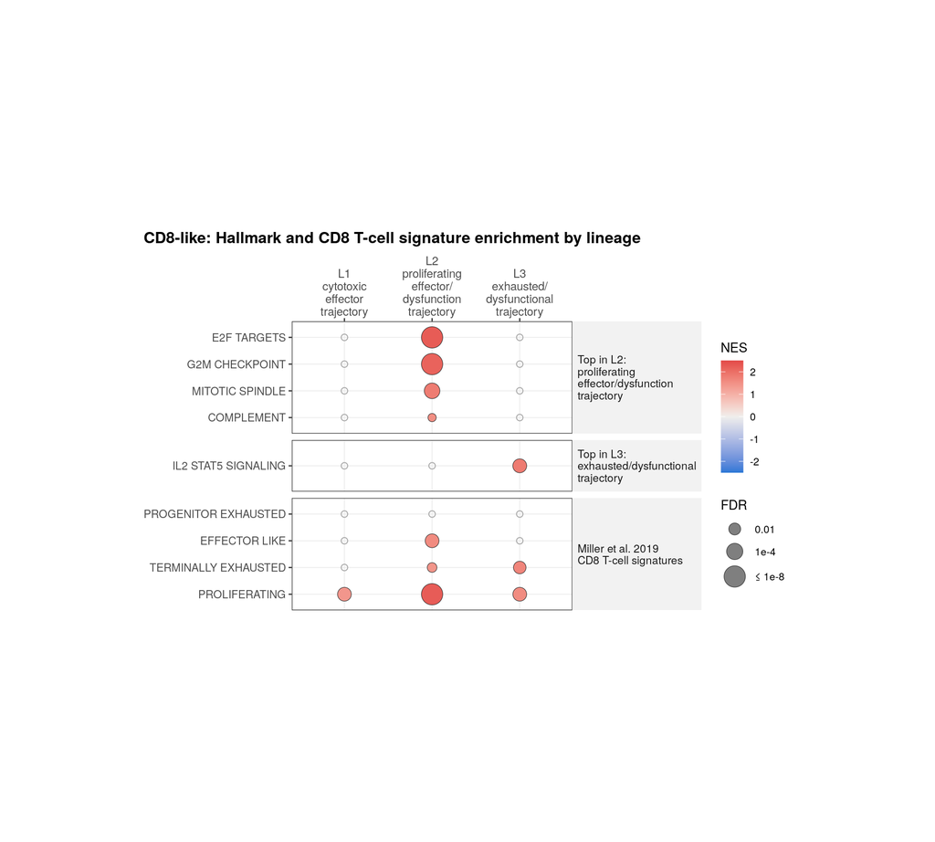

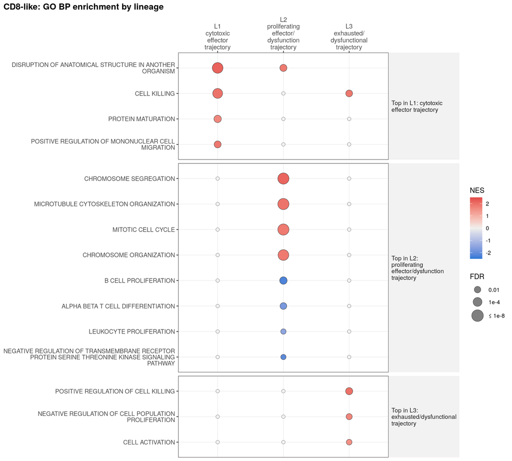